# Ridge, Lasso penalty

hw7

hanbyeol true  
04-15-2021

# **hw6에 이어 Ridge, Lasso penalty를 시각적으로 표현함!!(밑에부터 달라짐)**

# 1. Outlier 제거

outlier를 제거하기 위해 데이터를 다시 불러와서 시작한당 준비단계….

## 1.1 Libraries

```r
library(tidymodels)
library(tidyverse)
library(magrittr)
library(skimr)
library(knitr)
theme_set(theme_bw())
```

## 1.2 Data load

```r
file_path <- "/cloud/project"
files <- list.files(file_path)
files
```

```
 [1] "_posts"                "_site.yml"
 [3] "about.Rmd"             "blog_posts.Rmd"
 [5] "docs"                  "index.Rmd"
 [7] "Portfolio.Rmd"         "postcard.R"
 [9] "project.Rproj"         "README.md"
[11] "sample_submission.csv" "test.csv"
[13] "tobi.jpg"              "train.csv"
[15] "뭐에 쓴거임.Rmd"       "프사.jpg"
```

```r
test <- read_csv(file.path(file_path, "test.csv"))%>%
  janitor::clean_names()
train <- read_csv(file.path(file_path, "train.csv"))%>%
  janitor::clean_names()
```

## 1.3 Outliers 확인하기

- gr_liv_area 변수에 있는 outlier를 확인해보자!
- Any thoughts about right 4 points?

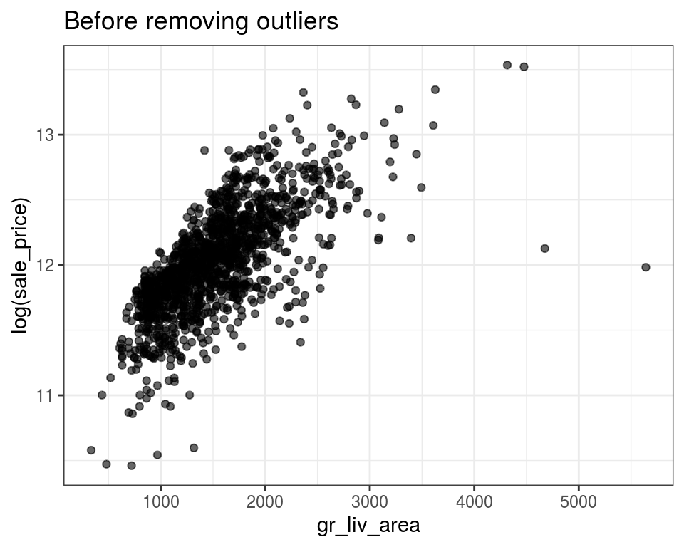

```r
train %>%
  ggplot(aes(x = gr_liv_area,
             y = log(sale_price))) +
  geom_point(alpha = 0.6) +
  labs(title = "Before removing outliers")
```

4500이상 되는 값들이 유독 튀는 것을 확인 할 수 있다. 4500 이상 되는 2개의 값을 필터 씌운 뒤에 다시 train data로 넣어보자 **%<>%**

```r
# outliers
train %>%
  filter(gr_liv_area > 4500) %>%
  DT::datatable(width = "100%",
                options = list(scrollX = TRUE))
```

|  | id | ms_sub_class | ms_zoning | lot_frontage | lot_area | street | alley | lot_shape | land_contour | utilities | lot_config | land_slope | neighborhood | condition1 | condition2 | bldg_type | house_style | overall_qual | overall_cond | year_built | year_remod_add | roof_style | roof_matl | exterior1st | exterior2nd | mas_vnr_type | mas_vnr_area | exter_qual | exter_cond | … |
| --- | --- | --- | --- | --- | --- | --- | --- | --- | --- | --- | --- | --- | --- | --- | --- | --- | --- | --- | --- | --- | --- | --- | --- | --- | --- | --- | --- | --- | --- | --- |
| 1 | 524 | 60 | RL | 130 | 40094 | Pave |  | IR1 | Bnk | AllPub | Inside | Gtl | Edwards | PosN | PosN | 1Fam | 2Story | 10 | 5 | 2007 | 2008 | Hip | CompShg | CemntBd | CmentBd | Stone | 762 | Ex | TA | … |
| 2 | 1299 | 60 | RL | 313 | 63887 | Pave |  | IR3 | Bnk | AllPub | Corner | Gtl | Edwards | Feedr | Norm | 1Fam | 2Story | 10 | 5 | 2008 | 2008 | Hip | ClyTile | Stucco | Stucco | Stone | 796 | Ex | TA | … |

```r
# outliers remove
train %<>% filter(!(gr_liv_area > 4500))
```

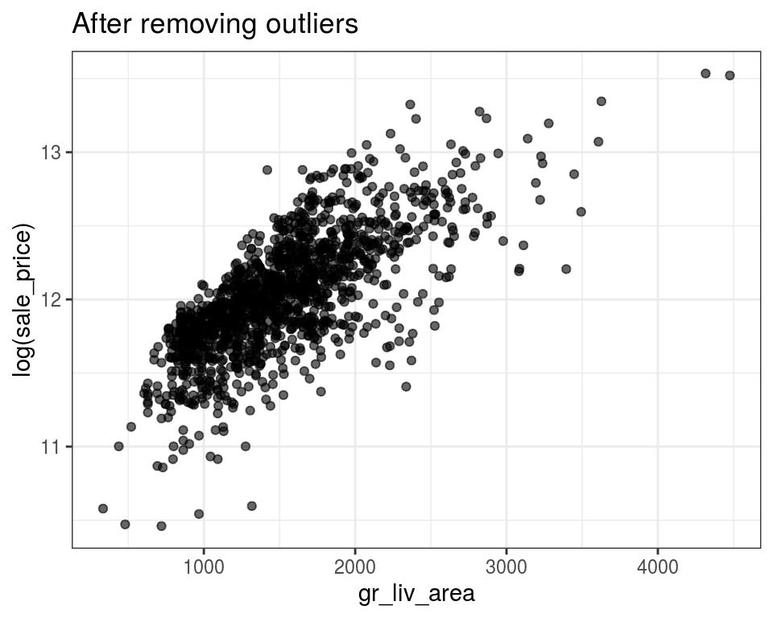

```r
train %>%
  ggplot(aes(x = gr_liv_area,
             y = log(sale_price))) +
  geom_point(alpha = 0.6) +
  labs(title = "After removing outliers")
```

outlier를 지우니 추세가 눈에 확 들어온다!

- total_bsmt_sf 변수에 있는 outlier를 확인해보자!

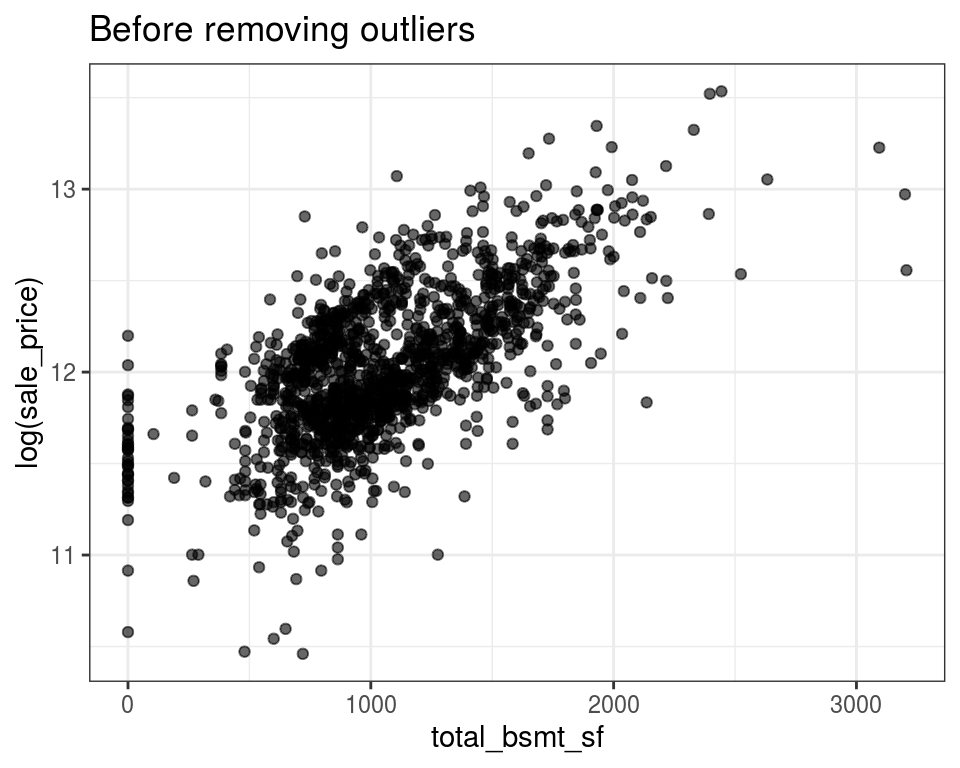

```r
train %>%
  ggplot(aes(x = total_bsmt_sf,
             y = log(sale_price))) +
  geom_point(alpha = 0.6) +
  labs(title = "Before removing outliers")
```

total_bsmt_sf가 3000 이상 되는 값들이 튀는 것처럼 보인다.

outlier점 3개중에 2개를 지웠다. (왜 로그값이 13보다 작은 값들을 지우셨는지는 좀 더 생각해보자)

```r
# outliers
train %>%
  filter(total_bsmt_sf > 3000 &
                   log(sale_price) < 13) %>%
  DT::datatable(width = "100%",
                options = list(scrollX = TRUE))
```

|  | id | ms_sub_class | ms_zoning | lot_frontage | lot_area | street | alley | lot_shape | land_contour | utilities | lot_config | land_slope | neighborhood | condition1 | condition2 | bldg_type | house_style | overall_qual | overall_cond | year_built | year_remod_add | roof_style | roof_matl | exterior1st | exterior2nd | mas_vnr_type | mas_vnr_area | exter_qual | exter_cond | … |
| --- | --- | --- | --- | --- | --- | --- | --- | --- | --- | --- | --- | --- | --- | --- | --- | --- | --- | --- | --- | --- | --- | --- | --- | --- | --- | --- | --- | --- | --- | --- |
| 1 | 333 | 20 | RL | 85 | 10655 | Pave |  | IR1 | Lvl | AllPub | Inside | Gtl | NridgHt | Norm | Norm | 1Fam | 1Story | 8 | 5 | 2003 | 2004 | Gable | CompShg | VinylSd | VinylSd | BrkFace | 296 | Gd | TA | … |
| 2 | 497 | 20 | RL |  | 12692 | Pave |  | IR1 | Lvl | AllPub | Inside | Gtl | NoRidge | Norm | Norm | 1Fam | 1Story | 8 | 5 | 1992 | 1993 | Hip | CompShg | BrkFace | BrkFace | None | 0 | Gd | TA | … |

```r
# outliers remove
train %<>% filter(!(total_bsmt_sf > 3000 &
                   log(sale_price) < 13))
```

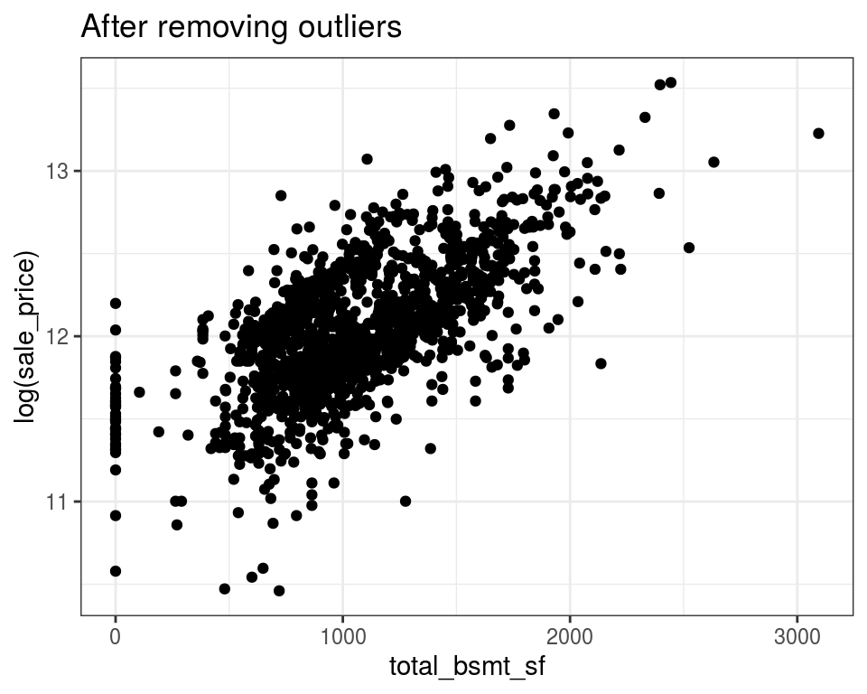

```r
train %>%
  ggplot(aes(x = total_bsmt_sf,
             y = log(sale_price))) +
  geom_point() +
  labs(title = "After removing outliers")
```

잘 지워졌당~!

- garage_area 변수에 있는 outlier를 확인해보자!

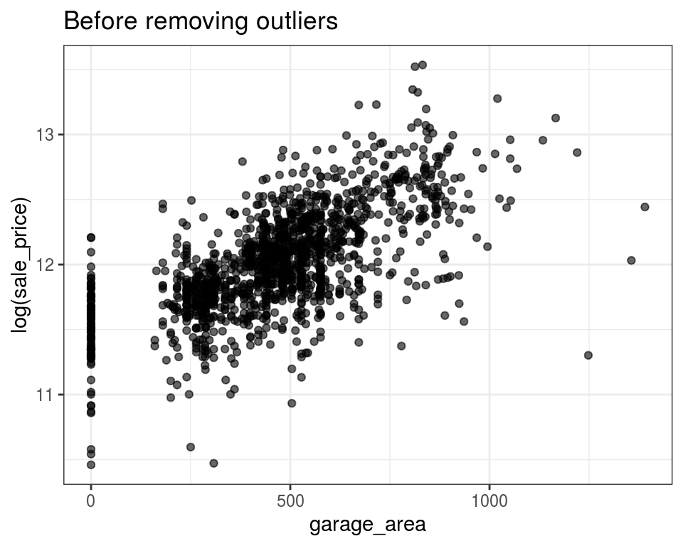

```r
train %>%
  ggplot(aes(x = garage_area,
             y = log(sale_price))) +
  geom_point(alpha = 0.6) +
  labs(title = "Before removing outliers")
```

1230보다 큰 3개의 점이 거슬린다.. 저걸 지워보쟈

```r
# outliers
train %>%
  filter(garage_area > 1230) %>%
  DT::datatable(width = "100%",
                options = list(scrollX = TRUE))
```

|  | id | ms_sub_class | ms_zoning | lot_frontage | lot_area | street | alley | lot_shape | land_contour | utilities | lot_config | land_slope | neighborhood | condition1 | condition2 | bldg_type | house_style | overall_qual | overall_cond | year_built | year_remod_add | roof_style | roof_matl | exterior1st | exterior2nd | mas_vnr_type | mas_vnr_area | exter_qual | exter_cond | … |
| --- | --- | --- | --- | --- | --- | --- | --- | --- | --- | --- | --- | --- | --- | --- | --- | --- | --- | --- | --- | --- | --- | --- | --- | --- | --- | --- | --- | --- | --- | --- |
| 1 | 582 | 20 | RL | 98 | 12704 | Pave |  | Reg | Lvl | AllPub | Inside | Gtl | NridgHt | Norm | Norm | 1Fam | 1Story | 8 | 5 | 2008 | 2009 | Hip | CompShg | VinylSd | VinylSd | BrkFace | 306 | Ex | TA | … |
| 2 | 1062 | 30 | C (all) | 120 | 18000 | Grvl |  | Reg | Low | AllPub | Inside | Gtl | IDOTRR | Norm | Norm | 1Fam | 1Story | 3 | 4 | 1935 | 1950 | Gable | CompShg | MetalSd | MetalSd | None | 0 | Fa | TA | … |
| 3 | 1191 | 190 | RL |  | 32463 | Pave |  | Reg | Low | AllPub | Inside | Mod | Mitchel | Norm | Norm | 2fmCon | 1Story | 4 | 4 | 1961 | 1975 | Gable | CompShg | MetalSd | MetalSd | Stone | 149 | TA | Gd | … |

```r
# outliers remove
train %<>% filter(garage_area <= 1230)
```

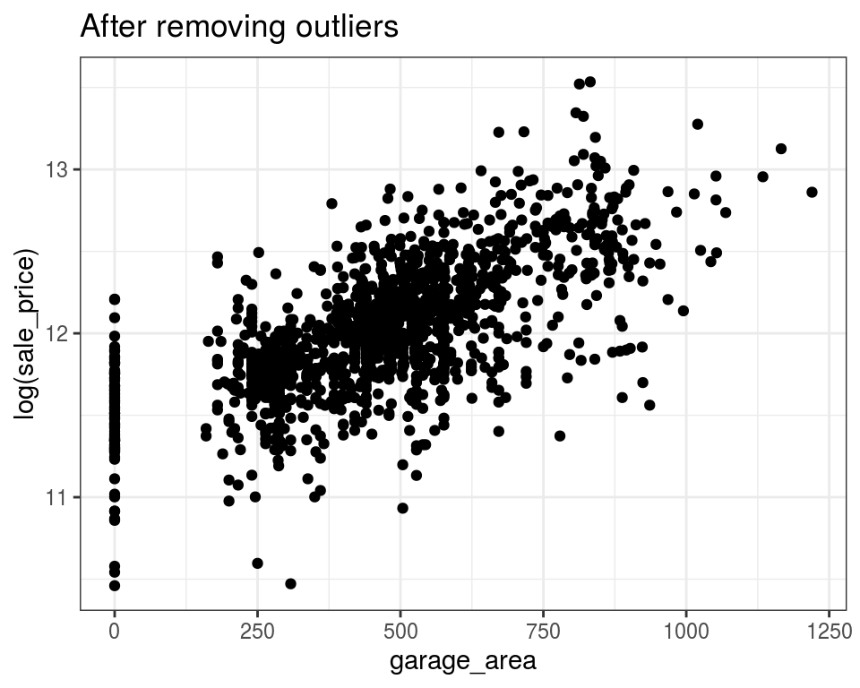

```r
train %>%
  ggplot(aes(x = garage_area,
             y = log(sale_price))) +
  geom_point() +
  labs(title = "After removing outliers")
```

잘 지워졌구나 ~!

# 2. training

이제 거슬리는 outliers을 지웠으니 학습을 통해 예측력을 높여보자 !!!

1번에서 outliers를 제거한 train set을 이용해서 training 해볼 것이다.!

먼저 outlier를 제거한 train과 test를 다시 전처리해준다.

```r
all_data <- bind_rows(train, test)
names(all_data)[1:10]
```

```
 [1] "id"           "ms_sub_class" "ms_zoning"    "lot_frontage"
 [5] "lot_area"     "street"       "alley"        "lot_shape"
 [9] "land_contour" "utilities"
```

- Make recipe

```r
housing_recipe <- all_data %>%
  recipe(sale_price ~ .) %>%
  step_rm(id) %>%
  step_log(sale_price) %>%
  step_modeimpute(all_nominal()) %>%
  step_dummy(all_nominal()) %>%
  step_meanimpute(all_predictors()) %>%
  step_normalize(all_predictors()) %>%
  prep(training = all_data)
print(housing_recipe)
```

```
Data Recipe

Inputs:

      role #variables
   outcome          1
 predictor         80

Training data contained 2912 data points and 2912 incomplete rows.

Operations:

Variables removed id [trained]
Log transformation on sale_price [trained]
Mode Imputation for ms_zoning, street, alley, ... [trained]
Dummy variables from ms_zoning, street, alley, ... [trained]
Mean Imputation for ms_sub_class, lot_frontage, ... [trained]
Centering and scaling for ms_sub_class, lot_frontage, ... [trained]
```

- `juice` the all_data2 and split

```r
all_data2 <- juice(housing_recipe)
```

We are done for preprocessing. Let’s split the data set.

```r
train_index <- seq_len(nrow(train))
train2 <- all_data2[train_index,]
test2 <- all_data2[-train_index,]
```

전처리가 다 끝났으면 이제 어떻게 학습할 것인지 알아보자

## 2.1 Elastic net

train set을 validation set으로 다시 분리 시킬 것이다. 70%는 학습용으로 남겨놓아라. 30%는 평가용!!

```r
set.seed(2021)
validation_split <- validation_split(train2, prop = 0.7)
#validation_split <- vfold_cv(train2, v = 10, strata = sale_price)
# actual split id stored in the following
# validation_split$splits[[1]]$in_id
# the whole point is that it's there and trust tidymodels :)
# head(validation_split$splits[[1]]$in_id)
```

이것이 실제로 어떻게 나눠져 있는지 확인하려면

in_id : 학습 할 때 사용하는 것 out_id : 평가 할 때 사용하는 것

```r
validation_split$splits[[1]]$in_id
```

```
   [1]    1    2    3    4    5    6    9   11   13   14   15   16
  [13]   18   19   21   22   23   24   25   26   28   30   31   32
  [25]   33   34   35   36   37   38   39   40   42   45   46   50
  [37]   51   52   54   56   58   61   62   64   65   66   67   68
  [49]   69   71   72   73   74   78   80   82   83   85   86   87
  [61]   88   90   91   92   94   96   97   99  100  102  104  105
  [73]  106  108  109  110  111  112  114  115  117  119  120  121
  [85]  122  124  125  126  128  130  131  132  133  135  136  137
  [97]  138  140  141  142  143  144  145  146  147  149  150  151
 [109]  152  153  157  158  159  160  161  162  163  165  168  169
 [121]  170  171  173  176  180  181  182  183  184  186  188  189
 [133]  190  193  194  195  196  197  200  201  202  203  204  206
 [145]  207  208  209  210  211  212  213  214  215  216  217  218
 [157]  219  220  221  222  223  224  225  228  229  231  233  234
 [169]  236  237  238  239  242  243  244  245  247  248  249  250
```

[output cut: 70 more lines]

```r
head(validation_split$splits[[1]]$in_id)
```

```
[1] 1 2 3 4 5 6
```

### 2.1.1 Ridge Regression

이제 tune을 해야하는데 Elastic net에서 $\alpha$(=mixture),penalty(=lambda)

ridge regression: Mixture=0

penalty는 아직 안정했음 : tune 할 것이다.

- Set the tuning spec 람다의 후보군을 여러개 남기기 위해서

*tune_spec*: ridge regression에 penalty는 아직 정해지지 않은 상태

*glmnet*: elastic net을 사용하기 위한 packaages

*param_grid* : 후보가 될 수 있는 람다의 값이 들어있음(하나하나 학습 시킬 것)0이 없고, 1이 무한대인 상태!

```r
tune_spec <- linear_reg(penalty = tune(),
                        mixture = 0) %>% #ridge
  set_engine("glmnet")
param_grid <- grid_regular(penalty(), levels = 100)
```

- Set workflow()

평가하기 위한 모델을 만들기

```r
workflow <- workflow() %>%
  add_model(tune_spec) %>%
  add_formula(sale_price ~ .)
```

어떤 것이 좋은지 평가하는 방식은 rmse(soot mean square error)를 이용하겠다.

-> *tune_result*에 각 람다 값에 대한 퍼포먼스가 담기게 된다.

```r
library(tictoc)
doParallel::registerDoParallel()
tic()
tune_result <- workflow %>%
  tune_grid(validation_split,
            grid = param_grid,
            metrics = metric_set(rmse))
toc()
```

```
0.906 sec elapsed
```

*collect_metrics()*: 퍼포먼스가 담긴 것들을 모아봐라

*mean* 값: rmse값(validation에서 나온 것 들의 평균)

우리의 목표: **mean 값이 최소**가 되는 **penalty**값을 구하는 것

```r
tune_result %>%
  collect_metrics()
```

```
# A tibble: 100 x 7
    penalty .metric .estimator  mean     n std_err .config
      <dbl> <chr>   <chr>      <dbl> <int>   <dbl> <chr>
 1 1.00e-10 rmse    standard   0.120     1      NA Preprocessor1_Mode…
 2 1.26e-10 rmse    standard   0.120     1      NA Preprocessor1_Mode…
 3 1.59e-10 rmse    standard   0.120     1      NA Preprocessor1_Mode…
 4 2.01e-10 rmse    standard   0.120     1      NA Preprocessor1_Mode…
 5 2.54e-10 rmse    standard   0.120     1      NA Preprocessor1_Mode…
 6 3.20e-10 rmse    standard   0.120     1      NA Preprocessor1_Mode…
 7 4.04e-10 rmse    standard   0.120     1      NA Preprocessor1_Mode…
 8 5.09e-10 rmse    standard   0.120     1      NA Preprocessor1_Mode…
 9 6.43e-10 rmse    standard   0.120     1      NA Preprocessor1_Mode…
10 8.11e-10 rmse    standard   0.120     1      NA Preprocessor1_Mode…
# … with 90 more rows
```

- Visualization of the tunning result

mixture은 지금 없으니까(ridge) 잠시 나가있어

```r
tune_best <- tune_result %>% select_best(metric = "rmse")
tune_best$penalty
```

```
[1] 0.03853529
```

```r
# tune_best$mixture
```

tune_result안네 penalty대비 rmse의 값을 보여주는 plot

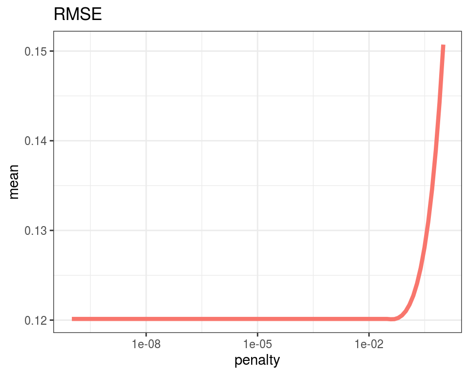

```r
tune_result %>%
  collect_metrics() %>%
  #filter(mixture == tune_best$mixture) %>%
  ggplot(aes(penalty, mean, color = .metric)) +
  geom_line(size = 1.5) +
  scale_x_log10() +
  theme(legend.position = "none") +
  labs(title = "RMSE")
```

*show_best()*: mean값을 최소로 만들어주는 값들의 몇개를 보여준다

```r
tune_result %>% show_best()
```

```
# A tibble: 5 x 7
   penalty .metric .estimator  mean     n std_err .config
     <dbl> <chr>   <chr>      <dbl> <int>   <dbl> <chr>
1 3.85e- 2 rmse    standard   0.120     1      NA Preprocessor1_Model…
2 4.86e- 2 rmse    standard   0.120     1      NA Preprocessor1_Model…
3 1.00e-10 rmse    standard   0.120     1      NA Preprocessor1_Model…
4 1.26e-10 rmse    standard   0.120     1      NA Preprocessor1_Model…
5 1.59e-10 rmse    standard   0.120     1      NA Preprocessor1_Model…
```

- Set **Ridge regression model** and fitting

위에서 구한 값으로 train2를 학습시킨다.

```r
elastic_model <-
    linear_reg(penalty = tune_best$penalty, # 0.095
               mixture = 0) %>%
    set_engine("glmnet")
elastic_fit <-
    elastic_model %>%
    fit(sale_price ~ ., data = train2)
options(max.print = 10)
elastic_fit %>%
    tidy() %>%
    filter(estimate > 0.001)
```

```
# A tibble: 112 x 3
   term           estimate penalty
   <chr>             <dbl>   <dbl>
 1 (Intercept)    12.0      0.0385
 2 lot_frontage    0.0109   0.0385
 3 lot_area        0.0177   0.0385
 4 overall_qual    0.0553   0.0385
 5 overall_cond    0.0358   0.0385
 6 year_built      0.0292   0.0385
 7 year_remod_add  0.0195   0.0385
 8 mas_vnr_area    0.00380  0.0385
 9 bsmt_fin_sf1    0.0269   0.0385
10 bsmt_fin_sf2    0.00818  0.0385
# … with 102 more rows
```

- Prediction

```r
result <- predict(elastic_fit, test2)
result %>% head()
```

```
# A tibble: 6 x 1
  .pred
  <dbl>
1  11.7
2  12.0
3  12.1
4  12.2
5  12.2
6  12.0
```

```r
X <- model.matrix(sale_price ~ ., train2)[, -1]

Y <- log(train2$sale_price)
```

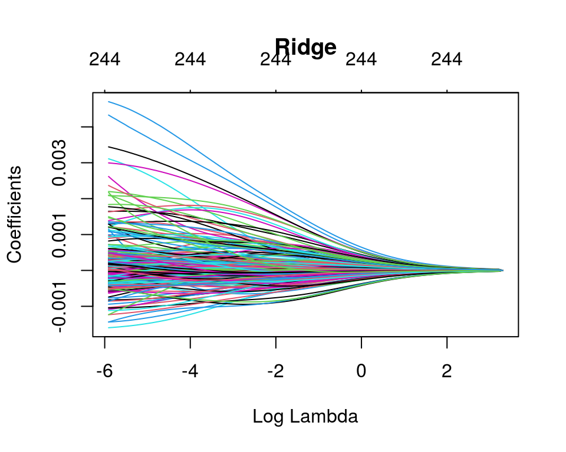

```r
# Apply ridge regression to ames data
ridge <- glmnet(
  x = X,
  y = Y,
  alpha = 0
)

plot(ridge, xvar = "lambda", main="Ridge")
```

[figure not shown]

```r
# Lasso model
lasso_min <- glmnet(
  x = X,
  y = Y,
  alpha = 1
)
plot(ridge, xvar = "lambda", main="Lasso")
```

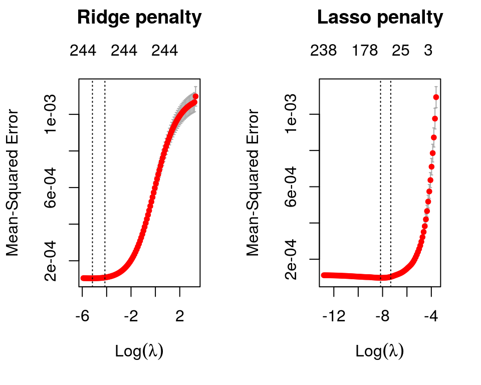

```r
# Apply CV ridge regression to Ames data
ridge <- cv.glmnet(
  x = X,
  y = Y,
  alpha = 0
)

# Apply CV lasso regression to Ames data
lasso <- cv.glmnet(
  x = X,
  y = Y,
  alpha = 1
)

# plot results
par(mfrow = c(1, 2))
plot(ridge, main = "Ridge penalty\n\n")
plot(lasso, main = "Lasso penalty\n\n")
```

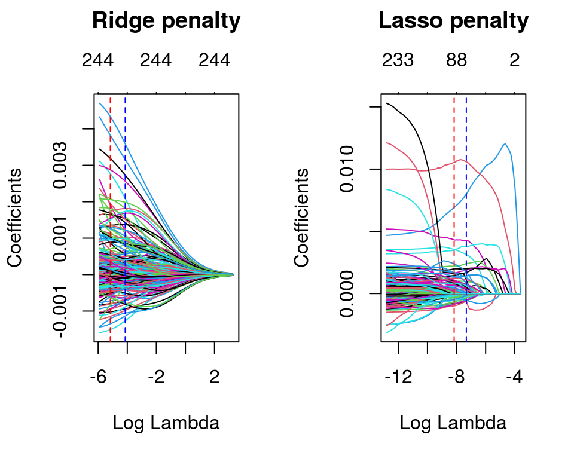

```r
# Ridge model
ridge_min <- glmnet(
  x = X,
  y = Y,
  alpha = 0
)

# Lasso model
lasso_min <- glmnet(
  x = X,
  y = Y,
  alpha = 1
)

par(mfrow = c(1, 2))
# plot ridge model
plot(ridge_min, xvar = "lambda", main = "Ridge penalty\n\n")
abline(v = log(ridge$lambda.min), col = "red", lty = "dashed")
abline(v = log(ridge$lambda.1se), col = "blue", lty = "dashed")

# plot lasso model
plot(lasso_min, xvar = "lambda", main = "Lasso penalty\n\n")
abline(v = log(lasso$lambda.min), col = "red", lty = "dashed")
abline(v = log(lasso$lambda.1se), col = "blue", lty = "dashed")
```

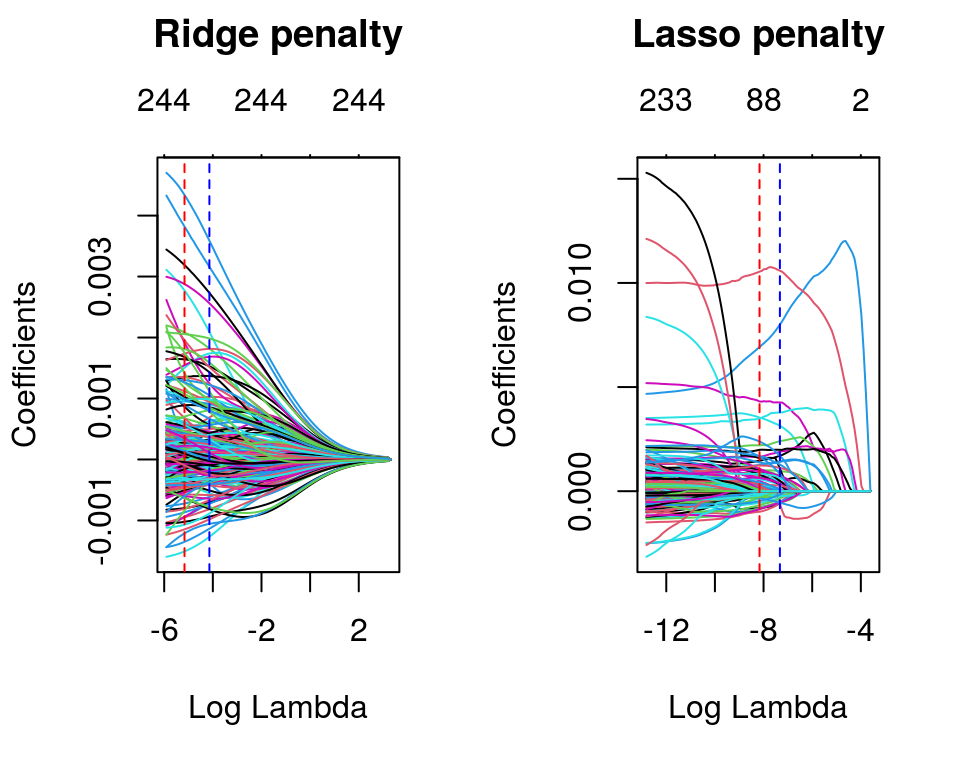

```r
# Ridge model
ridge_min <- glmnet(
  x = X,
  y = Y,
  alpha = 0
)

# Lasso model
lasso_min <- glmnet(
  x = X,
  y = Y,
  alpha = 1
)

par(mfrow = c(1, 2))

# plot ridge model
plot(ridge_min, xvar = "lambda", main = "Ridge penalty\n\n")
abline(v = log(ridge$lambda.min), col = "red", lty = "dashed")
abline(v = log(ridge$lambda.1se), col = "blue", lty = "dashed")

# plot lasso model
plot(lasso_min, xvar = "lambda", main = "Lasso penalty\n\n")
abline(v = log(lasso$lambda.min), col = "red", lty = "dashed")
abline(v = log(lasso$lambda.1se), col = "blue", lty = "dashed")
```